# BGC_class_models_CV.Rmd

We will carry out a series of CV procedures to evaluate the performance of the BGC class RC models. First, let’s load the R packages we will need.

And load and transform the data.

```r
TBL_DOM <- read.table(file = "data/metagenomes_dom_annot_wide_general.tsv",
                      header=T, sep="\t", row.names = 1)
TBL_CLASS <- read.table(file = "data/ref_genomes_class_cov_wide_general.tsv",
                        header=T, sep="\t", row.names = 1)


data <- inner_join(x = tibble::rownames_to_column( TBL_DOM/rowSums(TBL_DOM) ),
                   y = tibble::rownames_to_column(TBL_CLASS/rowSums(TBL_CLASS) ),
                   by = "rowname" )
```

We will use some custom R functions necessary to carry out the cross-validation procedures. Although there are some R packages that do this, by using our functions, it easier to have full control of the process.

1. create_cv_objects() randomly defines the training and testing groups. It creates a matrix storing the row numbers that will be used in each CV procedure and a vector that specifies which rows will be used as the training and testing groups.
2. run_cv() consist of three nested for loops that run the CV procedures according to the training and testing groups defined by create_cv_objects(), and computes the Mean Squared Error and Pearson Correlation Coefficient between for each iteration.

```r
source(file = "./toolbox.R")
```

We will carry out 100 three fold CV procedures.

Now we will extract Mean Squared Error and Pearson Correlation coefficient of model_cv_results.

```r
f <- function(x) lapply(x, "[[", "mse") %>% do.call("rbind", .)
mse <- lapply(model_cv_results, f ) %>%
       plyr::ldply(., data.frame)
colnames(mse) <- c("class","mse")


f <- function(x) lapply(x, "[[", "cor") %>% do.call("rbind", .)
cors <- lapply(model_cv_results, f ) %>%
        plyr::ldply(., data.frame)
colnames(cors) <- c("class","cor")
```

We will use the mse and cor data framse to plot the distribution of MSE and correlation coefficients.

```r
pmse <- ggplot(mse, aes(x = class, y = mse, fill = class)) +
        geom_jitter(alpha = .1) +
        geom_violin( aes(fill = class), alpha = .5,  trim = T, scale = "width" ) +
        stat_summary(fun.y = median ,geom='point', size = 0.5) +
        xlab("BGC class") +
        ylab("Mean Squared Error") +
        theme_light() +
        scale_fill_hue(c=70, l=40,h.start = 200,direction = -1) +
        theme( axis.text.y =  element_text(size= 8, color = "black"),
               axis.text.x =  element_text(size= 8, color = "black", angle = 45, hjust = 1) ,
               axis.title.x = element_text(size = 10, color = "black" , margin = unit(c(2, 0, 0, 0),"mm") ),
             axis.title.y = element_text(size = 10, color = "black", margin = unit(c(0, 5, 5, 0),"mm") ) ) +
      scale_x_discrete(position = "bottom") +
      guides(fill=FALSE)

pcor <- ggplot(cors, aes(x = class, y = cor, fill = class)) +
       geom_jitter(alpha = .1) +
       geom_violin( aes(fill = class), alpha = .5, trim = T, scale = "width") +
       #geom_boxplot(alpha = .5) +
       stat_summary(fun.y = median ,geom='point', size = 0.5) +
       xlab("BGC class") +
       ylab("Pearson's correlation coefficient") +
       theme_light() +
       scale_fill_hue(c=70, l=40,h.start = 200,direction = -1) +
       theme( axis.text.y =  element_text(size = 8, color = "black"),
              axis.text.x = element_blank(),
             # axis.text.x = element_text(size = 6, color = "black", angle = 45, hjust = 1 ),
              axis.title.x = element_blank(),
              axis.title.y = element_text(size = 10, color = "black", margin = unit(c(0, 5, 0, 0),"mm") ) ) +
      scale_x_discrete(position = "bottom") +
      guides(fill=FALSE)
```

And visualize them together.

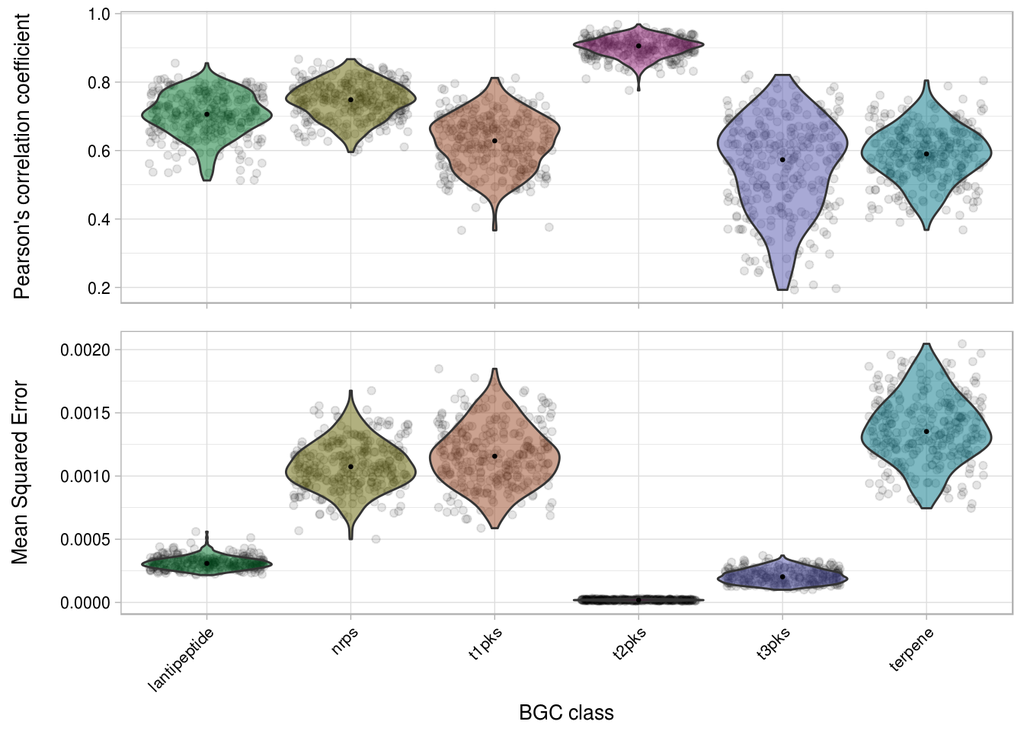

```r
plot_grid(pcor,pmse, nrow = 2, align = "v",
          rel_heights = c(0.7,0.9) )
```

Lastly, let’s see how the correlation looks like in a scatter plot. For this, we will select the first CV procedure.

First, we have to extract the predicted and real RC of the first iteration for each BGC class.

```r
X <- lapply(model_cv_results, "[[",1  ) %>%
     plyr::ldply(., data.frame) %>%
     .[,1:3]
colnames(X) <- c("class","real","pred")
```

Now we can plot the real vs the predicted.

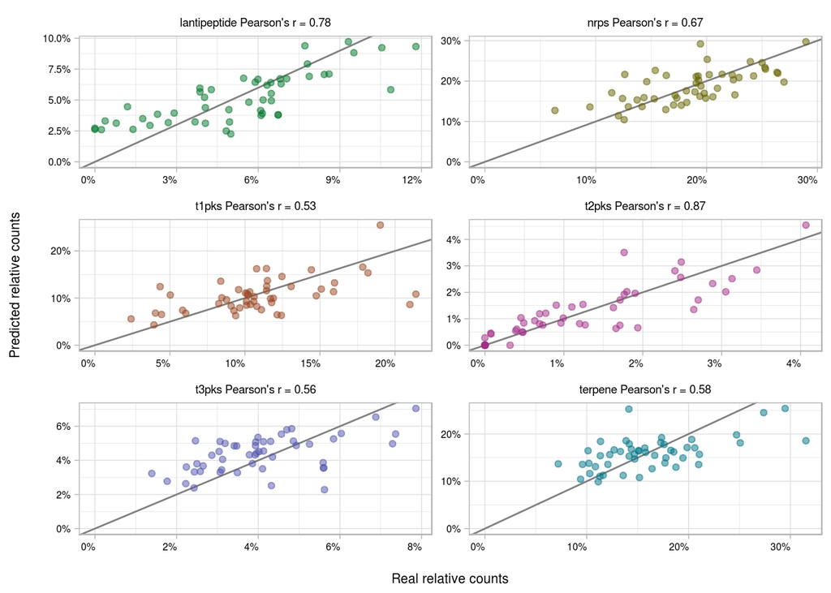

```r
# in this command, we will just create a title for each BGC class including the Pearson correlation coefficient.
class2cor <- X %>%
             group_by(class) %>%
             summarise(cor = cor(x = real, y = pred ) ) %>%
             as.data.frame()
class2cor$cor <- round(class2cor$cor,2)
titles <- paste(class2cor$class, "Pearson's r =", class2cor$cor)
names(titles) <- class2cor$class

# this is the plot
ggplot(X, aes(x = real, y = pred, color =  class ) ) +
  geom_abline(intercept = 0, slope = 1, color = "gray50") +
  geom_point( alpha = 0.5) +
  scale_color_hue(c=70, l=40,h.start = 200,direction = -1) +
  facet_wrap( ~ class, ncol = 2, nrow = 4, scales = "free", labeller = as_labeller(titles)) +
  xlab("Real relative counts") +
  ylab("Predicted relative counts") +
  theme_light() +
  expand_limits(y=0, x=0) +
  scale_x_continuous(labels = scales::percent) +
  scale_y_continuous(labels = scales::percent) +
  theme( axis.text.y =  element_text(size = 6, color = "black" ),
         axis.text.x =  element_text(size = 6, color = "black", hjust = 1 ),
         axis.title.x = element_text(size = 8, color = "black", margin = unit(c(5, 0, 0, 0),"mm") ),
         axis.title.y = element_text(size = 8, color = "black", margin = unit(c(0, 5, 0, 0),"mm") ),
         strip.text.x = element_text(size = 7, colour = "black" ),
         strip.background = element_blank(),
         strip.text = element_text(color = "black", size=6) ) +
  guides(color=FALSE)
```